# 经济与商务实证研究方法 - 第 4 周：DiD 方法的前沿拓展

完整讲义：从匹配 DiD 到合成 DiD，再到交错 DiD 与面板匹配

作者

单位

陈志远

中国人民大学商学院

发布于

2026年5月23日

# 1 引言

W3 我们建立了经典 2×2 DiD 的识别与推断框架：两组两期、平行趋势、聚类标准误。但现实里的政策评估几乎不会出现在这样干净的设定里——处理单位选择往往依赖可观测的混杂因素、政策分批推进、某些研究只有*一个*处理单位。本讲把 W3 的工具箱拓展到四个更现实的方向。

*第一条线*是匹配与半参数。当处理组与对照组在协变量分布上*本身*就不同时，即使做了 2×2 DiD，平行趋势也可能被未观测的组间差异污染。倾向得分匹配 DiD（PSM-DID）、Abadie (2005) 的半参数 DiD，都是为了解决这个问题。

*第二条线*是合成化。当研究只有一个处理单位（加州 Prop 99、英国脱欧、海南自贸港），DiD 无法直接使用——合成控制法（SCM）和它的现代继承者*合成 DiD*（Arkhangelsky et al., 2021）填补了这个空白。

*第三条线*是交错处理。Goodman-Bacon (2021) 证明 TWFE 在交错处理下可能给出*错误符号*的估计量——这是最近十年计量学界最大的一场震动。Callaway-Sant’Anna、Sun-Abraham、de Chaisemartin-D’Haultfoeuille、Borusyak-Jaravel-Spiess 提供了系统的修复方案。

*第四条线*是动态与历史。Ashenfelter (1978) 提醒我们过去的 $Y$ 本身就是时变混杂；Imai-Kim-Wang (2021) 用面板匹配的语言系统地刻画“条件在 $L$ 期历史之后的 ATT”——对不稳定、可逆的政策尤其有用。

## 1.1 上节课回顾

W3 的核心要点：面板数据解锁了组内变异，固定效应扣除时不变异质性；经典 2×2 DiD 在“平行趋势 + 无预期”下识别 ATT；TWFE 回归与 DiD 估计量在 2×2 下等价；推断必须聚类到政策分配的最细层级。本讲的六个话题都可视为 W3 框架在不同维度上的拓展：PSM-DID 拓展了“对照组构造”，合成 DiD 拓展了“单位权重”，交错 DiD 拓展了“多时点多组群”，Imai-Kim-Wang 拓展了“时间路径条件化”。

# 2 第一部分：倾向得分匹配 DiD

## 2.1 从潜在结果到选择偏误

把“是否选修 RMEB 课程”看作一个二元决定 $D_i \in \{0, 1\}$，未来收入 $Y_i$ 是我们关心的结果变量。每个学生都有两种潜在结果：选修下的收入 $Y_i^1$ 和不选修下的收入 $Y_i^0$。我们只能观测到一个：

$$Y_i = D_i Y_i^1 + (1 - D_i) Y_i^0$$

受处理组的平均效应（ATT）定义为

$$ATT = E[Y_i^1 - Y_i^0 \mid D_i = 1, \boldsymbol{X}_i]$$

但我们无法同时观测 $Y_i^1$ 和 $Y_i^0$。最朴素的做法是用对照组的结果近似处理组的反事实：

$$\underbrace{E[Y_i \mid D = 1, \boldsymbol{X}] - E[Y_i \mid D = 0, \boldsymbol{X}]}_{\text{观测差异}} = \underbrace{\delta(\boldsymbol{X})}_{ATT \mid \boldsymbol{X}} + \underbrace{E[Y_i^0 \mid D = 1, \boldsymbol{X}] - E[Y_i^0 \mid D = 0, \boldsymbol{X}]}_{\text{选择偏误}}$$

右端第二项就是*选择偏误*：处理组与对照组的“无政策下结果”的系统差异。选择偏误为 0 时，观测差异直接识别 ATT；当它不为 0 时，简单比较就会偏。

### 2.1.1 条件独立假设（CIA）

一个关键的识别假设是 Rubin 的 CIA：

$$Y_i^0 \perp D_i \mid \boldsymbol{X}_i$$

在 $\boldsymbol{X}_i$ 给定的前提下，处理状态相当于*随机指派*。此时 $Bias(\boldsymbol{X}_i) = 0$，ATT 可识别。Angrist (1998) 研究自愿服兵役时即用此假设。

CIA 的*失效*场景：当不可观测特征（能力、偏好、私人信息）同时驱动 $D$ 与 $Y^0$ 时，CIA 不成立。实证研究的核心任务之一就是论证 CIA 的合理性——这通常需要制度背景、数据结构与稳健性检查三者合力。

### 2.1.2 回归与匹配：两种加权

“Regression can be motivated as a particular sort of weighted matching estimator.” (Angrist & Pischke) 匹配与回归最大的区别在*权重结构*：

- *匹配估计量*把权重放在 $\Pr(D=1 \mid \boldsymbol{X})$ 较高的协变量格子上——这些格子“更接近处理组”；
- *回归*则把权重放在 $\Pr(D=1 \mid \boldsymbol{X}) \cdot [1 - \Pr(D=1 \mid \boldsymbol{X})]$ 较大的格子上——处理 / 对照比例接近 50:50 的区域权重最高。

*共同支撑*（Common Support）要求 $0 < \Pr(D=1 \mid \boldsymbol{X}) < 1$：若某些 $\boldsymbol{X}$ 值下*没有*处理单位，或*没有*对照单位，权重无法定义，估计量无解。实证中必须先画倾向得分的分布重叠图才能继续。

## 2.2 倾向得分匹配（PSM）

当 $\boldsymbol{X}$ 的维度很高，逐维匹配在有限样本下几乎不可行。Rosenbaum & Rubin (1983) 的突破是：在 CIA 成立时，匹配*倾向得分*就够了。

**排除限制**（Heckman-Ichimura-Todd, 1998）：把 $\boldsymbol{X}$ 拆成 $(\boldsymbol{T}, \boldsymbol{Z})$：

$$Y_i^0 = g_0(\boldsymbol{T}_i) + U_i^0, \quad Y_i^1 = g_1(\boldsymbol{T}_i) + U_i^1$$
$$\Pr(D_i = 1 \mid \boldsymbol{X}_i) = \Pr(D_i = 1 \mid \boldsymbol{Z}_i) = P(\boldsymbol{Z}_i)$$

$\boldsymbol{T}$ 进入潜在结果方程，$\boldsymbol{Z}$ 进入选择方程，两者不必互斥。识别 ATT 只需要*弱一些*的假设：

$$U_i^0 \perp D_i \mid P(\boldsymbol{Z}_i) \quad (\text{PSM 下的 CIA})$$

这是一个结构式的解释——把 PSM 嵌入经济学的选择模型：

$$D_i = \mathbb{1}\{\lambda(\boldsymbol{Z}_i) - v \geq 0\}$$

若 $\boldsymbol{Z} \perp v$，则 $P(\boldsymbol{Z}) = F_v[\lambda(\boldsymbol{Z})]$；若再有 $\lambda(\boldsymbol{Z}) \perp (U^0, v)$ 且 $E(U^0) = 0$，则对任意 $s$ 有 $E(U^0 \mid v = s) = 0$——不可观测维度上不再选择。

## 2.3 PSM-DID：把匹配嫁接到面板

单期横截面的 PSM 能处理*可观测混杂*，但对不可观测的时不变混杂束手无策。面板数据给我们一个额外的差分机会：

$$\hat{\delta}^{PSM\text{-}DID}(\boldsymbol{X}) = E[Y_{i1} - Y_{i0} \mid \boldsymbol{X}, D_{i1} = 1] - E[Y_{i1} - Y_{i0} \mid \boldsymbol{X}, D_{i1} = 0]$$

在平行趋势假设下，这个量恰好识别 ATT：

$$\hat{\delta}^{PSM\text{-}DID} = E[U_i^1 - U_i^0 \mid P(\boldsymbol{Z}), D = 1] - E[U_i^1 - U_i^0 \mid P(\boldsymbol{Z}), D = 0]$$

PSM-DID 比单期 PSM 多承担两件事：

- 允许*选择依赖于潜在结果的水平*：个体固定效应被差分掉；
- 允许*部分不可观测维度上的选择*：只要那些维度时不变。

### 2.3.1 实施步骤

1. 用 `probit` 或 `logit` 估计 $P(\boldsymbol{Z}_i)$；
2. 按*队列-年份*在 $\hat{P}(\boldsymbol{Z}_i)$ 上做最近邻匹配；
3. 生成差分结果 $\Delta Y_{it} = Y_{it} - Y_{i0}$，加权聚合到 $ATT_{gt}$。

推断依赖 Abadie & Imbens (2006) 的解析标准误（考虑匹配引入的额外不确定性）；Stata 命令 `teffects psmatch` 直接支持。

### 2.3.2 Stata 实战：完整 DGP（Lab §2）

以下代码复现配套实验室 `L4-Diff-in-Diffs-More.ipynb` 中的 DGP：

```stata
* ===== DGP：500 个体 × 2 期面板 =====
clear all
set seed 10101
set obs 500
g id = _n
g lambda = rnormal(0, 0.5)                 // 个体固定效应
expand 2
bys id: g t = _n - 1
g x  = rnormal(0, 1)
g u1 = rnormal(0, 0.2)
g u0 = rnormal(0, 0.2)
g v  = rnormal(0, 1) if t == 1             // 选择方程噪声
scalar delta  = 0.1                        // 时间趋势
scalar alpha1 = 0.1
scalar alpha2 = 0.2
g y0 = alpha1*x + alpha2*x^2 + lambda + delta*t + u0
g y1 = alpha1*x + alpha2*x^2 + lambda + delta*t + u1
g D  = 0
bys id (t): replace D = 1 if t == 1 & x > v   // x 大的单位进入处理
g tau_u = cond(D == 1, 0.15, 0)            // 真实 ATT = 0.15
replace y1 = y1 + tau_u if D == 1
g y = D*y1 + (1 - D)*y0
save simdata_did1.dta, replace
```

### 2.3.3 估计倾向得分 + 重叠检查

```stata
qui probit D x       if t == 1
predict pr1 if t == 1

qui probit D x x^2   if t == 1            // 非线性倾向得分
predict pr2 if t == 1

twoway (hist pr1 if t==1 & D==1, color(blue%30)) ///
       (hist pr1 if t==1 & D==0, color(red%30)), ///
       legend(order(1 "treated" 2 "control")) ///
       title("Propensity Score Overlap")
```

### 2.3.4 PSM-DID 估计与近邻数敏感性

```stata
tsset id t
g dy = y - l.y                             // 差分结果

* 不同近邻数下的 ATT
matrix Res = J(10, 3, .)
forv i = 1/10 {
    qui teffects psmatch (dy) (D x, probit) if t==1, ///
        atet nn(`i') vce(robust)
    matrix Res[`i', 1] = (_b[r1vs0.D], _se[r1vs0.D], `i')
}
```

**实操建议**：2–5 个近邻是稳健的默认选择；若 ATT 对近邻数极度敏感，说明重叠不好或处理效应异质。

### 2.3.5 Python 演示：PSM-DID 的核心思想

下面用 Python 直接复现 DGP 并比较“TWFE vs. PSM-DID”：

**点击查看 PSM-DID Python 代码**

```
真实 ATT             = 0.150
朴素差分（有偏）      = 0.142
PSM-DID（1 近邻）     = 0.128
```

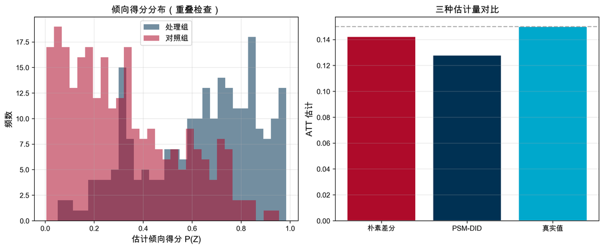

```python
from sklearn.linear_model import LogisticRegression
from scipy.spatial.distance import cdist

rng = np.random.default_rng(10101)
n = 500
lam = rng.normal(0, 0.5, n)
x = rng.normal(0, 1, n)
v = rng.normal(0, 1, n)
D = (x > v).astype(int)
delta, a1, a2 = 0.1, 0.1, 0.2
tau_true = 0.15

# t = 0, 1
def outcome(t, d):
    u = rng.normal(0, 0.2, n)
    base = a1*x + a2*x**2 + lam + delta*t
    return base + u + (tau_true * d if t == 1 else 0)

y0 = outcome(0, np.zeros(n, dtype=int))
y1 = outcome(1, D)
dy = y1 - y0

# (1) 朴素差分
naive = dy[D == 1].mean() - dy[D == 0].mean()

# (2) PSM-DID：用 logit(x, x^2) 估计倾向得分，1-近邻匹配
X = np.c_[x, x**2]
ps = LogisticRegression().fit(X, D).predict_proba(X)[:, 1]
ps_treated = ps[D == 1]
ps_control = ps[D == 0]
dy_treated = dy[D == 1]
dy_control = dy[D == 0]

# 为每个处理单位找最近邻对照
dist = cdist(ps_treated.reshape(-1, 1), ps_control.reshape(-1, 1))
nn_idx = dist.argmin(axis=1)
matched_control = dy_control[nn_idx]
psm_did = (dy_treated - matched_control).mean()

print(f"真实 ATT             = {tau_true:.3f}")
print(f"朴素差分（有偏）      = {naive:.3f}")
print(f"PSM-DID（1 近邻）     = {psm_did:.3f}")

# 可视化倾向得分分布
fig, ax = plt.subplots(1, 2, figsize=(12, 5))
ax[0].hist(ps[D == 1], bins=30, alpha=0.55, color='#003153', label='处理组')
ax[0].hist(ps[D == 0], bins=30, alpha=0.55, color='#AE0B2A', label='对照组')
ax[0].set_xlabel('估计倾向得分 P(Z)', fontsize=12)
ax[0].set_ylabel('频数', fontsize=12)
ax[0].set_title('倾向得分分布（重叠检查）', fontsize=13)
ax[0].legend(fontsize=11)
ax[0].grid(alpha=0.3)

ax[1].bar(['朴素差分', 'PSM-DID', '真实值'],
          [naive, psm_did, tau_true],
          color=['#AE0B2A', '#003153', '#00A8CC'],
          edgecolor='white')
ax[1].axhline(tau_true, color='gray', linestyle='--', alpha=0.6)
ax[1].set_ylabel('ATT 估计', fontsize=12)
ax[1].set_title('三种估计量对比', fontsize=13)
ax[1].grid(axis='y', alpha=0.3)
plt.tight_layout()
plt.show()
```

# 3 第二部分：半参数 DiD

Abadie (2005, *ReStud*) 给出了一个*权重形式*的 ATT 表达，既不必显式选择近邻，也不要求协变量进入线性回归。其核心恒等式：

$$E[Y_{i1}^1 - Y_{i1}^0 \mid \boldsymbol{X}, D_{i1} = 1] = E[\rho_0 (Y_{i1} - Y_{i0}) \mid \boldsymbol{X}]$$

其中权重为

$$\rho_0 = \frac{D_{i1} - P(D_{i1} = 1 \mid \boldsymbol{X})}{P(D_{i1} = 1 \mid \boldsymbol{X}) \cdot [1 - P(D_{i1} = 1 \mid \boldsymbol{X})]}$$

取期望得到

$$ATT = E\left[\frac{Y_{i1} - Y_{i0}}{P(D = 1)} \cdot \frac{D_{i1} - P(D_{i1} = 1 \mid \boldsymbol{X})}{1 - P(D_{i1} = 1 \mid \boldsymbol{X})}\right]$$

直觉：用倾向得分对*差分后的结果*加权，让对照组被重新加权成与处理组可比的反事实。这与 IPW（Inverse Probability Weighting）同源。

### 3.0.1 子群 ATT

对子集 $\boldsymbol{X}^{sub}_i$ 的 ATT 可以通过求解如下最小化问题得到：

$$\hat{\delta}(\boldsymbol{X}^{sub}) = \arg\min_\theta E\{P(D_{i1} = 1 \mid \boldsymbol{X}) \cdot [\rho_0 (Y_{i1} - Y_{i0}) - g(\boldsymbol{X}^{sub}; \theta)]^2\}$$

*估计步骤*：

1. 估计倾向得分 $\hat{P}(D = 1 \mid \boldsymbol{X})$（用 probit 或 logit）；
2. 把拟合值代入样本类比式，得到 $\widehat{ATT}$ 或其子群拓展。

Stata 命令 `absdid` 直接封装了这一流程。手工实现也很简单：

```stata
use simdata_did1.dta, clear
qui logit D x if t == 1
predict pr1 if t == 1
egen pD = mean(D) if t == 1
tsset id t
gen ab_diff = (y - l.y)/pD * ((D - pr1)/(1 - pr1)) if t == 1
qui sum ab_diff if t == 1
display "半参数 ATT = " r(mean) ", SE = " r(sd)

* 或直接调用 absdid
g dy = y - l.y
absdid dy, tvar(D) xvar(x) sle
```

真实 ATT = 0.15，半参数估计值应该落在 0.14–0.16 附近。

# 4 第三部分：合成 DiD

## 4.1 合成控制法：背景

合成控制法（SCM）由 Abadie & Gardeazabal (AER 2003) 首创，Abadie, Diamond & Hainmueller (JASA 2010) 给出完整统计理论。核心思想是：当只有一个（或极少数）处理单位时，用对照池的*凸组合*构造合成反事实：

$$\hat{Y}_{1t}^{SCM} = \sum_{j=2}^{J+1} \omega_j^* \cdot Y_{jt}$$

权重 $\omega_j^* \geq 0$，$\sum_j \omega_j^* = 1$，通过最小化处理前结果路径的匹配距离来选择：

$$\min_\omega (X_1 - X_0 \omega)^\top V (X_1 - X_0 \omega)$$

**经典案例：加州 Proposition 99**。1988 年加州通过控烟法案大幅提高烟草税。用其他 38 个州合成加州：Utah 33%、Nevada 23%、Montana 20%、Colorado 14%、Connecticut 10%。1989–2000 年实际加州的人均香烟消费比合成反事实低约 26 包/年。

## 4.2 合成 DiD 的目标函数

Arkhangelsky et al. (AER 2021) 提出合成 DiD（SDiD），同时引入*单位权重* $\omega_i^{sc}$ 和*时期权重* $\lambda_t^{sc}$：

$$(\hat{\delta}^{sdid}, \hat{\mu}, \hat{\alpha}_i, \hat{\beta}_t) = \arg\min \sum_i \sum_t (Y_{it} - \mu - \alpha_i - \beta_t - \delta D_{it})^2 \cdot \omega_i^{sc} \cdot \lambda_t^{sc}$$

**直觉**

- *像 SCM*：单位权重让处理前路径匹配 → 弱化对平行趋势的依赖；
- *像 DiD*：保留 TWFE 结构 → 允许大面板渐近推断、允许多个处理单位。

DiD 是 SDiD 的特例（所有权重相等）；SCM 也是 SDiD 的特例（只有单位权重、不考虑时期权重）。

### 4.2.1 何时用 SDiD

- 处理组不止一个，但个数有限且平行趋势不太放心；
- 对照池丰富；
- 需要 bootstrap / jackknife 推断而非置换检验；

### 4.2.2 Stata 实战：SDiD（Lab §4）

```stata
use simdata_did1.dta, clear
g x2 = x^2

* 合成 DiD（自带单位 + 时期权重）
sdid y id t D, covariates(x x2, projected) ///
    vce(bootstrap) seed(123)

* 提取单位权重 omega（仅存在于 t==1 且 D==0 的对照单位）
g omega = .
qui sum D if t==1 & D==0
qui forv i = 1/`r(N)' {
    scalar uw     = e(omega)[`i', 1]
    scalar ctr_id = e(omega)[`i', 2]
    replace omega = uw if id == ctr_id
}

* 权重 × 协变量的投影：合成样本的代表性
g x_proj = x * omega
ta t, sum(x_proj)
```

**权重诊断**是 SDiD 的*核心透明度*：权重集中（少数对照单位承担主要作用）→ 可解释性强；权重分散 → 更接近 TWFE，平行趋势要求更严。论文应常规地报告单位权重分布图。

# 5 第四部分：交错处理下的 TWFE 陷阱

## 5.1 交错处理是常态

中国自贸区从 2013 年上海开始、2015 年扩至闽粤津、2017-2020 年再陆续覆盖其他省份；美国无过错离婚法在 37 个州于 1969–1985 年间分批通过；企业数字化转型则完全由企业内生决定时点。交错处理（staggered treatment）是常态而非例外。

最直觉的做法是把 TWFE 直接扩展：

$$Y_{it} = \alpha_i + \lambda_t + \delta D_{it} + \varepsilon_{it}$$

形式上与 2×2 一样。但 Goodman-Bacon (2021, *JoE*) 证明，在交错处理下这个 $\hat{\delta}$ 的含义已经*面目全非*。

## 5.2 Goodman-Bacon 分解定理

**定理**。设数据包含 $k = 1, \ldots, K$ 个按处理时点排序的组群。TWFE 估计量等于*所有可能的 2×2 DiD*的加权平均：

$$\hat{\delta}^{TWFE} = \sum_{j \neq U} s_{jU} \hat{\beta}_{jU}^{2 \times 2} + \sum_{k < \ell} s_{k\ell} \left[\mu_{k\ell} \hat{\beta}_{k\ell}^{2\times 2, k} + (1 - \mu_{k\ell}) \hat{\beta}_{k\ell}^{2\times 2, \ell}\right]$$

其中三种 2×2 DiD 估计量是

$$\hat{\beta}_{jU}^{2\times 2} = (\bar{Y}_j^{post(j)} - \bar{Y}_j^{pre(j)}) - (\bar{Y}_U^{post(j)} - \bar{Y}_U^{pre(j)})$$

$$\hat{\beta}_{k\ell}^{2\times 2, k} = (\bar{Y}_k^{mid(k,\ell)} - \bar{Y}_k^{pre(k)}) - (\bar{Y}_\ell^{mid(k,\ell)} - \bar{Y}_\ell^{pre(k)})$$

$$\hat{\beta}_{k\ell}^{2\times 2, \ell} = (\bar{Y}_\ell^{post(\ell)} - \bar{Y}_\ell^{mid(k,\ell)}) - (\bar{Y}_k^{post(\ell)} - \bar{Y}_k^{mid(k,\ell)})$$

$K$ 个时点组产生 $K^2$ 个 2×2 DiD：$K$ 个“处理 vs 从未”比较 + $K(K-1)$ 个“处理 vs 已处理”比较。权重之和为 1，但*可能为负*。

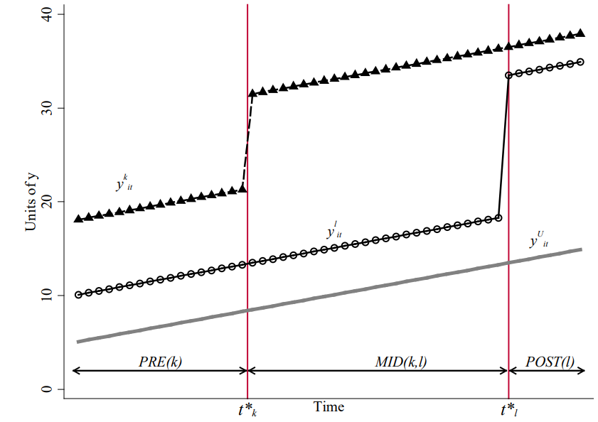

图 1: 三组三期的几何直觉

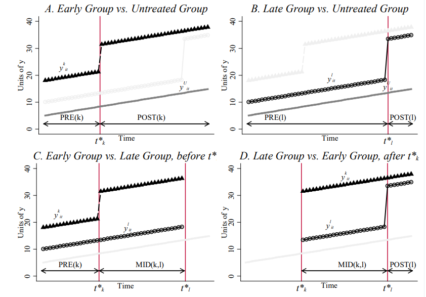

图 2: 四种 2×2 DiD 组合

## 5.3 权重公式

每个 2×2 DiD 的权重由*子样本大小的平方*和*固定效应调整后处理变量的方差*共同决定：

$$s_{jU} = \frac{(n_j + n_U)^2 \hat{V}_{jU}^D}{\hat{V}^D}$$

$$s_{k\ell}^k = \frac{[(n_k + n_\ell)(1 - \bar{D}_\ell)]^2 \hat{V}_{k\ell}^{D,k}}{\hat{V}^D}, \quad s_{k\ell}^\ell = \frac{[(n_k + n_\ell) \bar{D}_k]^2 \hat{V}_{k\ell}^{D,\ell}}{\hat{V}^D}$$

样本的*子样本方差*在两个时点组规模相近、或处理时点接近时间窗口中部时最大——这些比较的权重就最大。这意味着 TWFE 会*放大*规模相当、时点居中的比较，*缩小*边缘样本的影响。

## 5.4 VWATT-VWCT-ΔATT 分解

Goodman-Bacon 进一步证明 TWFE 系数可以解释为：

$$\hat{\delta}^{TWFE} = \underbrace{VWATT}_{\text{方差加权 ATT}} - \underbrace{VWCT}_{\text{方差加权共同趋势}} + \underbrace{\Delta ATT}_{\text{偏误项}}$$

- $VWATT = \sum_{k \neq U} \sigma_{kU} ATT_k^{post(k)} + \sum_{k < \ell} [\sigma_{k\ell}^k ATT_k^{mid(k,\ell)} + \sigma_{k\ell}^\ell ATT_\ell^{post(\ell)}]$
- $VWCT = 0$ 若平行趋势成立
- $\Delta ATT = \sum_{k<\ell} \sigma_{k\ell} [ATT_k^{post(\ell)} - ATT_k^{mid(k,\ell)}]$

**负权重的根源**。当早处理组 $k$ 在晚处理组 $\ell$ 的“post”期继续累积效应（$ATT_k^{post(\ell)} > ATT_k^{mid(k,\ell)}$）时，$\Delta ATT > 0$——TWFE 把这部分“累积”误读为“控制组的趋势下降”，从而让新处理组 $\ell$ 的系数被下拉。极端情况下，$\hat{\delta}^{TWFE}$ 可以与真实平均 ATT *符号相反*。

**解读 TWFE 的三条结论**：

1. 即使 $\Delta ATT = 0$（效应在时间上不变），权重仍是样本份额与处理方差的函数，$VWATT$ 一般不等于样本 ATT；
2. 效应在时间上变化（$\Delta ATT \neq 0$）时，TWFE 给出实际不可信的估计；
3. *始终处理组*作为新处理组的对照，最容易引发偏误——Roth 等人的经验是*先检查 Bacon 分解再报告 TWFE 系数*。

## 5.5 案例：无过错离婚法对女性自杀率的影响

Stevenson & Wolfers (2006) 利用 37 个州无过错离婚法的*分批通过*作为自然变异。Goodman-Bacon (2021) 重新审视这一研究。事件研究估计显示后处理期的平均效应 $\approx -4.92$，但 TWFE 系数仅为 $-3.08$。差距从何而来？

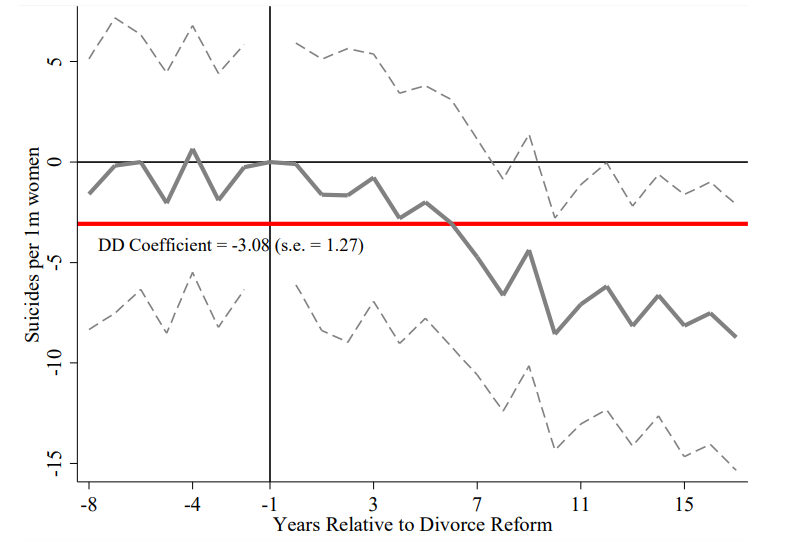

图 3: 离婚法事件研究

`bacondecomp` 命令给出完整的权重分解：

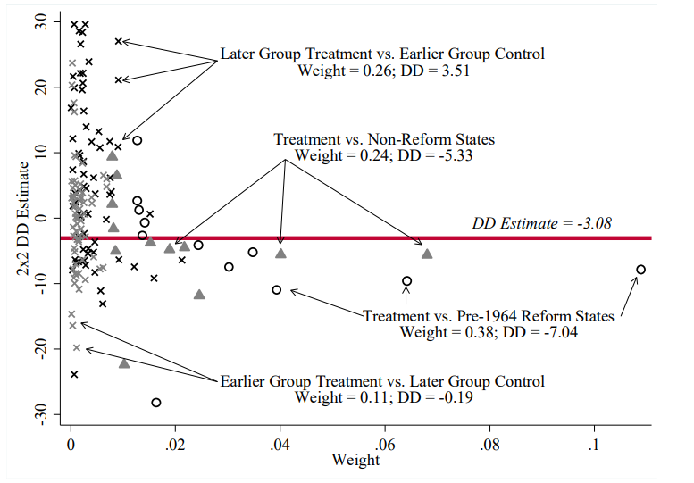

图 4: 离婚法 Bacon 权重分解

- 时点比较权重总和：$s_{k\ell}^k + s_{k\ell}^\ell = 0.26 + 0.11 = 0.37$（这部分有偏误）
- 处理-从未对照权重：$s_{jU} = 0.38 + 0.24 = 0.62$
- *排除“晚 vs 早”*：ATT = -5.45
- *再排除“始终处理 vs 新处理”*：ATT = -3.71

## 5.6 Stata 实战：Bacon 分解（Lab §5）

配套实验室使用 Borusyak et al. (2021) 的交错 DGP 模板：

```stata
* ===== 交错处理 DGP =====
clear all
set seed 10
global T = 15
global I = 500
set obs `=$I * $T'
gen i  = int((_n - 1)/$T) + 1
gen t  = mod((_n - 1), $T) + 1
tsset i t
gen Ei = ceil(runiform() * 7) + $T - 6 if t == 1   // 首次处理年份 10..16
bys i (t): replace Ei = Ei[1]
gen K  = t - Ei                                    // 相对处理期
gen D  = K >= 0 & Ei != .
gen tau = cond(D == 1, (t - 12.5), 0)             // 动态效应
gen Y   = i + 3*t + tau*D + rnormal()

* Bacon 分解
qui xtreg Y D i.t, fe robust
ssc install bacondecomp, replace
bacondecomp Y D, ddetail
```

典型输出会展示每种 2×2 DiD 的权重和估计值。在这个 DGP 下，“晚 vs 早”比较的权重约 10%，但估计值为负——正是 Goodman-Bacon 警告的 negative weight 现象。

# 6 第五部分：现代 DiD 估计量

## 6.1 共同原则

四个现代方法的共同修复思路：

1. *按组群-时期* $(g, t)$ 分别估计 $ATT(g, t)$；
2. *对照组*只使用“从未处理”或“尚未处理”的单位；
3. 按研究问题聚合——整体 ATT、事件时间 ATT、或组群 ATT。

## 6.2 Wooldridge (2021) 的 Mundlak 视角

Wooldridge 给出了一个优雅的诊断：“TWFE 并非估计方法本身有问题，问题在于它被应用到一个对处理效应异质性施加强假设的模型上。” 他的修复办法是把*完整的组群-时期交互项*放入回归：

$$E(Y_{it} \mid \boldsymbol{G}) = \eta + \sum_{g=2}^T \lambda_g G_{ig} + \sum_{s=2}^T \theta_s \mathbf{1}(t = s) + \sum_{g=2}^T \sum_{s=g}^T \tau_{g,s}(G_{ig} \cdot \mathbf{1}(t = s))$$

**识别假设**：

- *无预期*：$E[Y_t(g) - Y_t(\infty) \mid \boldsymbol{G}] = 0$ 当 $t < g$；
- *平行趋势*：$E[Y_t(\infty) - Y_1(\infty) \mid \boldsymbol{G}] = E[Y_t(\infty) - Y_1(\infty)] \equiv \theta_t$。

Mundlak 回归直接用 POLS 估计上述交互项；$\hat{\tau}_{g,s}$ 就是 $ATT(g, s)$。

## 6.3 Sun & Abraham (2021, JoE)

SA 的关键洞察：*传统的事件研究回归*

$$Y_{it} = \alpha_i + \lambda_t + \sum_e \beta_e \mathbf{1}(t - g_i = e) + \varepsilon_{it}$$

的系数 $\beta_e$ 在异质处理效应下*不是*事件时间 ATT 的平均——它被“已处理组的污染”扭曲。SA 的修复：把事件时间虚拟变量*与组群虚拟变量交互*：

$$Y_{it} = \alpha_i + \lambda_t + \sum_g \sum_{e \neq 0} \delta_{g,e} G_{ig} \cdot \mathbf{1}(t - g + 1 = e) + \varepsilon_{it}$$

$\hat{\delta}_{g,e}$ 一致估计 $ATT(g, g+e-1)$。报告的事件研究系数是按组群规模的加权平均：

$$\hat{\theta}(e) = \sum_g \hat{w}_g \hat{\delta}_{g, e+1}$$

**优势**：仍在回归框架内，协变量易加入； **劣势**：对“从未处理”或“最后处理”组群的假设更敏感。

### 6.3.1 Stata：`eventstudyinteract`

```stata
sum Ei
gen lastcohort = Ei == r(max)
forv l = 0/5 { gen L`l'event = (K == `l') }
forv l = 1/14 { gen F`l'event = (K == -`l') }
drop F1event    // 基准期 k = -1 设为 0

eventstudyinteract Y L*event F*event, vce(cluster i) ///
    absorb(i t) cohort(Ei) control_cohort(lastcohort)
matrix sa_b = e(b_iw)
matrix sa_v = e(V_iw)
```

## 6.4 Callaway & Sant’Anna (2021, JoE)

CS 放弃回归框架，直接在*非参数*层面定义 $ATT(g, t)$：

$$ATT(g, t) = E[Y_t(g) - Y_t(\infty) \mid G_g = 1]$$

*两种平行趋势假设*：

- **从未处理对照**：$E[Y_t^0 - Y_{t-1}^0 \mid G_g = 1] = E[Y_t^0 - Y_{t-1}^0 \mid C = 1]$
- **尚未处理对照**：$E[Y_t^0 - Y_{t-1}^0 \mid G_g = 1] = E[Y_t^0 - Y_{t-1}^0 \mid D_s = 1]$ （$s > t$）

对应两种 ATT 估计量：

$$\widehat{ATT}^{never}(g, t) = \frac{\sum_i G_{ig}(Y_{it} - Y_{i,g-1})}{\sum_i G_{ig}} - \frac{\sum_i C_i (Y_{it} - Y_{i,g-1})}{\sum_i C_i}$$

$$\widehat{ATT}^{ny}(g, t) = \frac{\sum_i G_{ig}(Y_{it} - Y_{i,g-1})}{\sum_i G_{ig}} - \frac{\sum_i C_i(1 - G_{ig})(Y_{it} - Y_{i,g-1})}{\sum_i C_i(1 - G_{ig})}$$

### 6.4.1 Stata：`csdid`

```stata
gen gvar = cond(Ei == ., 0, Ei)
csdid Y, ivar(i) time(t) gvar(gvar) notyet
estat event, estore(cs)             // 事件研究系数 + 95% CI
estat simple                        // 简单 ATT 聚合
```

## 6.5 de Chaisemartin & D’Haultfoeuille (2020, AER)

dCdH 关注*即期处理效应*：

$$\hat{\delta}^{dCdH} = \sum_{g=2}^T \hat{P}(G_g = 1 \mid \text{Treated for period} \geq 1) \cdot \widehat{ATT}(g, g)$$

其中

$$\widehat{ATT}^{ny}(g, t) = \frac{\sum_i G_{ig}(Y_{it} - Y_{i,g-1})}{\sum_i G_{it}} - \frac{\sum_i (1 - D_{it})(1 - G_{ig})(Y_{it} - Y_{i,g-1})}{\sum_i (1 - D_{it})(1 - G_{ig})}$$

dCdH 提供了动态扩展（`dynamic(F)`）与安慰剂检验（`placebo(P)`），推断基于 bootstrap。

### 6.5.1 Stata：`did_multiplegt`

```stata
did_multiplegt Y i t D, robust_dynamic dynamic(5) ///
    placebo(5) breps(100) cluster(i)
matrix dcdh_b = e(estimates)
matrix dcdh_v = e(variances)
```

## 6.6 Borusyak, Jaravel & Spiess (2024, ReStud)

BJS 的插补思想：

1. 用*未处理*观测 $(D_{it} = 0)$ 估计 TWFE 模型的 $\hat{\alpha}_i, \hat{\lambda}_t$；
2. 对处理观测插补反事实：$\hat{Y}_{it}(0) = \hat{\alpha}_i + \hat{\lambda}_t$；
3. 单位-时期效应：$\hat{\tau}_{it} = Y_{it} - \hat{Y}_{it}(0)$；
4. 按需聚合。

**BJS 的卖点**：

- 在齐次方差下效率最优（BLUE）；
- 推断基于*随机化*——小样本可靠，不依赖渐近理论；
- 自带对预趋势的正式检验。

### 6.6.1 Stata：`did_imputation`

```stata
did_imputation Y i t Ei, allhorizons pretrend(5)
estimates store bjs
```

## 6.7 四种方法对比

| 维度 | *CS* | *SA* | *dCdH* | *BJS* |
| --- | --- | --- | --- | --- |
| 框架 | 非参数 | 回归（IW） | 匹配式 | 插补 |
| 关注对象 | $ATT(g, t)$ | $\delta_{g, e}$ | 即期 ATT | 所有 $(i, t)$ |
| 对照组 | 从未 / 尚未 | 最后处理 | 从未 + 尚未 | 所有未处理观测 |
| 协变量 | 需显式加权 | 直接入回归 | 需显式加权 | 直接入回归 |
| 小样本 | Bootstrap | 渐近 | 渐近 | 正式随机化 |

**实务建议**

1. 主力方法用 *CS*（以 `csdid` 出默认结果）；
2. 事件研究图用 *SA*（以 `eventstudyinteract` 出带 CI 的图）；
3. 关注即期用 *dCdH*（以 `did_multiplegt` 出 robust_dynamic）；
4. 效率导向用 *BJS*（以 `did_imputation` 作为稳健性）。

至少报告其中两种，并说明结果一致或不一致的原因。

## 6.8 五种估计量在同一 DGP 上的对比

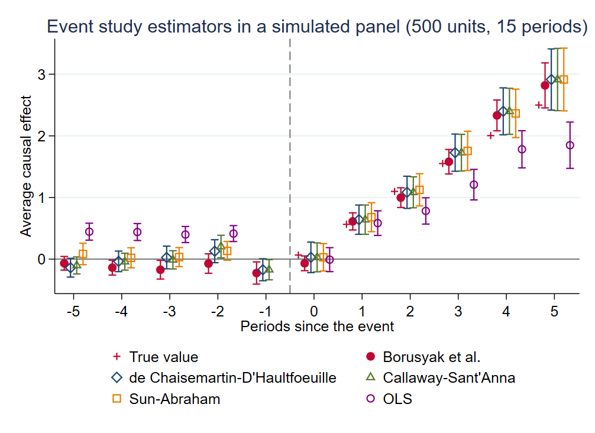

图 5: Five-estimator event study

这张图来自配套实验室 `L4-Diff-in-Diffs-More.ipynb` 的最后一个单元格。500 单位 × 15 期，处理时点在 10-16 年间随机分配，真实动态效应 $\tau_{it} = t - 12.5$ 当 $t \geq E_i$。OLS 事件研究在 post 期系统性偏低；四种现代估计量都与真值基本重合。

### 6.8.1 R 语言对照

```r
library(did)         # Callaway-Sant'Anna
library(fixest)      # Sun-Abraham via sunab()
library(DIDmultiplegt)
library(didimputation)

# CS
atts <- att_gt(yname = "Y", tname = "t", idname = "i",
               gname = "Ei", data = df, control_group = "notyettreated")
aggte(atts, type = "dynamic")

# SA via fixest
es <- feols(Y ~ sunab(Ei, t) | i + t, data = df, cluster = ~i)
iplot(es)

# dCdH
did_multiplegt(df, "Y", "i", "t", "D",
               robust_dynamic = TRUE, dynamic = 5, placebo = 5)

# BJS
did_imputation(data = df, yname = "Y", gname = "Ei",
               tname = "t", idname = "i", horizon = TRUE)
```

# 7 第六部分：当历史重要——Imai-Kim-Wang

## 7.1 动态经济变量

许多经济变量天然具有*自回归结构*：当期值依赖过去值。典型例子：

$$Y_{it} = \rho Y_{i,t-1} + X_{it}^\prime \alpha + \lambda_t + \mu_i + \varepsilon_{it}$$

迭代展开：

$$Y_{it} = \rho^t Y_{i0} + \sum_{s=0}^{t} \rho^s (X_{i,t-s}^\prime \alpha + \lambda_{t-s} + \mu_i + \varepsilon_{i,t-s})$$

当处理 $D_{it}$ 在 $t$ 期启动并长期维持时，效应会通过 $\rho$ 传递到后续所有期。

**Cobb-Douglas 生产函数** 是一个经典例子。生产率冲击自相关 $v_{it} = \rho v_{i,t-1} + e_{it}$，产出方程就带上了滞后项：

$$y_{it} = \rho y_{i,t-1} + (\beta_k k_{it} - \rho \beta_k k_{i,t-1}) + (\beta_l l_{it} - \rho \beta_l l_{i,t-1}) + (\gamma_t - \rho \gamma_{t-1}) + (1 - \rho)\eta_i + \xi_{it}$$

## 7.2 动态效应的三种尺度

假设处理在 $t = 0$ 启动并持续，真实瞬时效应为 $\delta$。

- *即期效应*：$\delta$
- *中期效应*（$F$ 期后）：$\delta \cdot \dfrac{1 - \rho^F}{1 - \rho}$
- *长期效应*：$\dfrac{\delta}{1 - \rho}$

一次性政策冲击在动态模型下会“回响”很久。报告哪种效应取决于研究问题：审稿人通常想看*动态效应全图*（event study）；政策建议强调*长期效应*；成本效益分析对应*中期效应*（预算周期）。

## 7.3 Ashenfelter (1978) 的 Dip

Ashenfelter 发现：接受职业培训的人，*在培训前*收入就出现一个“坑”——通常是因为失业、家庭变故等冲击触发了培训决定。如果直接用“培训前后”比较，这个 dip 会*夸大*培训的正效应。关键问题是：过去的 $Y_{i,t-1}$ 成为*时变混杂因子*，无法被固定效应吸收。

修正后的平行趋势假设：

$$E[Y_{it}(0) - Y_{i,t-1}(0) \mid D_{it}, \{Y_{i,t-\ell}\}_{\ell=1}^L, X_{it}] = E[Y_{it}(0) - Y_{i,t-1}(0) \mid \{Y_{i,t-\ell}\}_{\ell=1}^L, X_{it}]$$

在实务中这意味着*控制滞后因变量*，或使用 Imai, Kim & Wang (2021) 的面板匹配方法。

## 7.4 政策不稳定时的处理定义

$$\begin{array}{c|cccc|l}
& t=1 & t=2 & t=3 & t=4 & \text{类型} \\ \hline
i=1 & 0 & 1 & 1 & 1 & \text{稳定处理} \\
i=2 & 0 & 1 & 0 & 1 & \text{不稳定 I} \\
i=3 & 0 & 1 & 1 & 0 & \text{不稳定 II} \\
i=4 & 0 & 0 & 1 & 0 & \text{不稳定 III} \\
i=5 & 0 & 0 & 0 & 0 & \text{从未处理}
\end{array}$$

“什么是处理？”这个问题在政策不稳定时变得非平凡。三种应对：

1. *强制吸收态*：把曾被处理的单位都当作持续处理；
2. *进入 vs 退出分离*：ATT（进入效应）vs. ART（退出效应）；
3. *按历史路径条件化*：Imai-Kim-Wang 的核心思路。

## 7.5 ATT(F, L) 与 ART(F, L)

条件在相同的 $L$ 期历史上，Imai-Kim-Wang (2021, AJPS) 定义

$$ATT(F, L) = E\left[Y^{01}_{it+F}(L) - Y^{00}_{it+F}(L) \mid D_{it} = 1, D_{i,t-1} = 0\right]$$

$$ART(F, L) = E\left[Y^{10}_{it+F}(L) - Y^{11}_{it+F}(L) \mid D_{it} = 0, D_{i,t-1} = 1\right]$$

其中 $Y^{ab}_{it+F}(L)$ 表示当 $(D_{it}, D_{i,t-1}) = (a, b)$、$\{D_{i,t-\ell}\}_{\ell=2}^L$ 为任意给定历史时的潜在结果。

**$F$ 与 $L$ 的选择权衡**：

| 参数 | 大值的好处 | 大值的代价 |
| --- | --- | --- |
| $L$ | 更可信的历史条件 → carryover 效应被允许 | 匹配样本缩小 → 估计精度下降 |
| $F$ | 长期效应的信息 | 单位可能切换处理状态 → 解释困难 |

## 7.6 面板匹配估计量

**匹配集合**

$$\mathcal{M}_{it}^{ATT} = \{(m, t) \mid m \neq i, D_{mt} = 0, (D_{m, t-\ell})_{\ell=1}^L = (D_{i, t-\ell})_{\ell=1}^L\}$$

$$\mathcal{M}_{it}^{ART} = \{(n, t) \mid n \neq i, D_{nt} = 1, (D_{n, t-\ell})_{\ell=1}^L = (D_{i, t-\ell})_{\ell=1}^L\}$$

只有*完全相同的历史路径*的单位才能进入匹配集合。

**估计量**

$$\widehat{ATT(F, L)} = \frac{1}{\sum G_{it}} \sum_{i, t} G_{it} \left[Y^{01}_{it+F} - Y^0_{it-1} - \sum_{m \in \mathcal{M}_{it}} w_{it}^m (Y_{m, t+F} - Y_{m, t-1})\right]$$

- $G_{it} = (D_{it} - D_{i,t-1}) \cdot \mathbb{1}\{|\mathcal{M}_{it}| \geq 1\}$：只有“处理刚发生变化且有匹配”时才记录；
- 权重 $w_{it}^m$ 可用 Mahalanobis 距离 或 PSM。

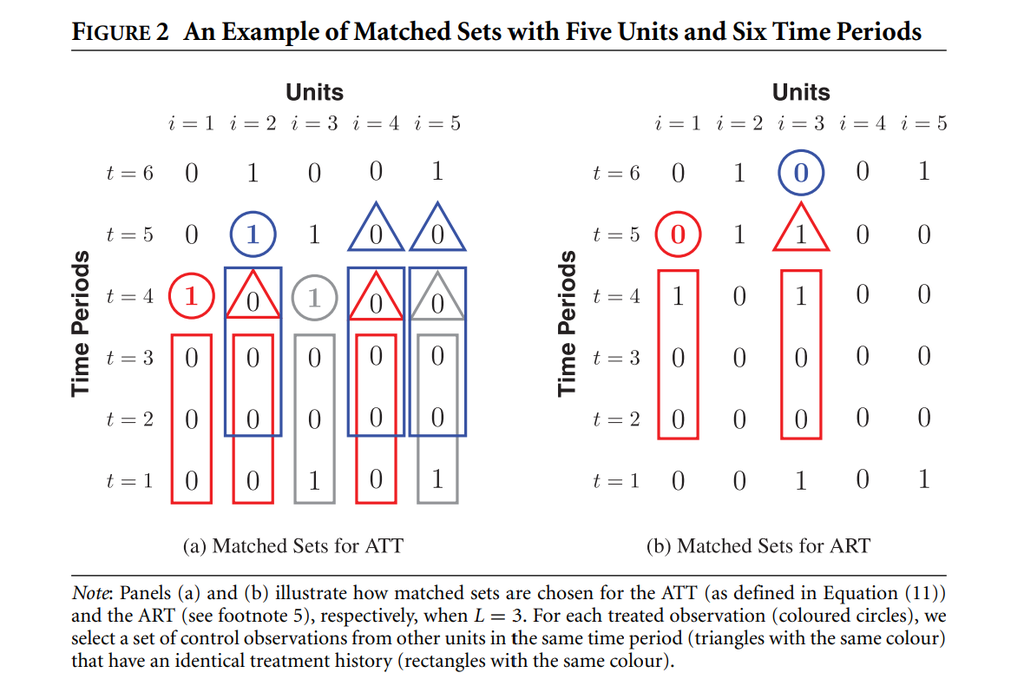

图 6: 面板匹配的时间结构

R 实现：`PanelMatch` 包（Imai, Kim & Wang 自家维护）。

# 8 第七部分：实务指南

## 8.1 平行趋势不放心时怎么办

**层层递进的应对**：

- 加入*丰富的协变量*：条件平行趋势；
- 强制*重叠条件*：每个处理单位存在 $\boldsymbol{X}$ 接近的对照；
- 检查*无预期*：处理前是否已有行为调整；
- 更换识别框架：IV、RD、SCM、CiC（quantile DiD）。

**不该做的事**：

- 简单“加个时间趋势”——往往吸收真实效应；
- 数据驱动地切样本——违反预注册；
- 说“通过了平行趋势检验”——这是错误措辞，只能说“未拒绝事前平行的假设”。

## 8.2 DID 研究的标准清单

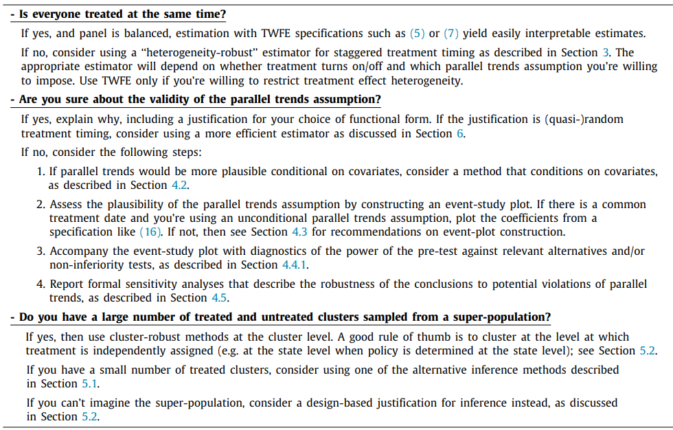

图 7: Roth et al. (2023) 的 DID 检查清单

Roth, Sant’Anna, Bilinski & Poe (JoE 2023) 的综述给出了一份写在论文审稿评论里的“必做清单”。审稿人读完正文先对着这份清单挑你没做的事——论文提前在附录里主动回答，是最稳妥的策略。

## 8.3 软件工具

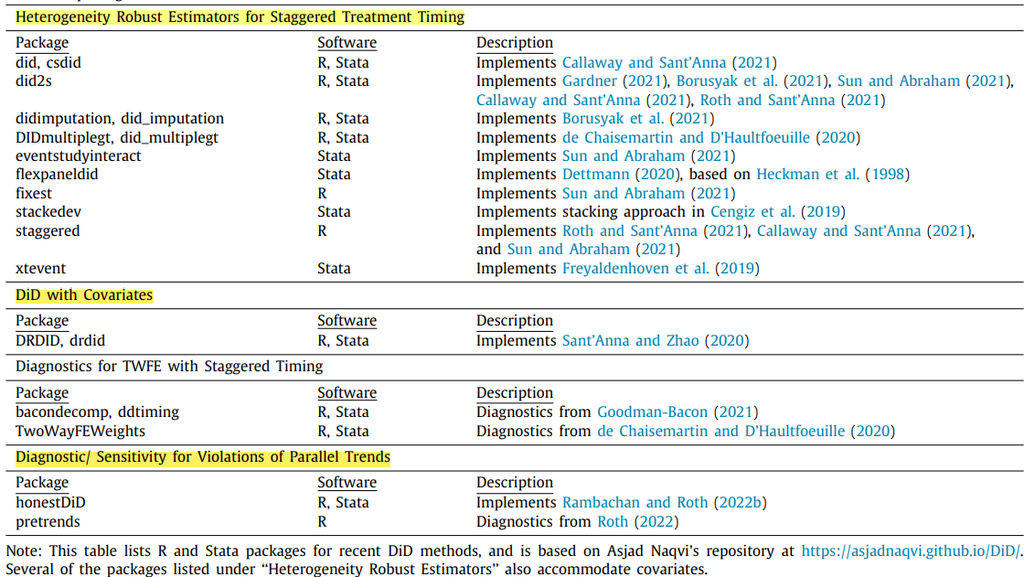

图 8: DID 现代估计量的软件支持

- *Stata*：`csdid`、`eventstudyinteract`、`did_multiplegt`、`did_imputation`、`sdid`、`bacondecomp`、`honestdid`、`absdid`、`teffects`
- *R*：`did`、`fixest`（`sunab()`、`i()`）、`synthdid`、`DIDmultiplegt`、`didimputation`、`HonestDiD`、`PanelMatch`

# 9 总结

## 9.1 本讲要点回顾

### 9.1.1 1. 匹配类 DiD 处理可观测混杂

PSM-DID（Heckman-Ichimura-Todd 1998）降维到倾向得分、做面板差分，允许选择依赖于潜在结果水平和时不变不可观测特征。半参数 DiD（Abadie 2005）用权重公式直接写出 ATT，不需要显式选择近邻。

### 9.1.2 2. 合成 DiD 融合 SCM 与 DiD

Arkhangelsky et al. (2021) 同时引入单位权重与时期权重，弱化平行趋势依赖，保留大面板推断。正在成为政策评估的默认方法。

### 9.1.3 3. TWFE 在交错处理下失灵

Goodman-Bacon (2021) 分解显示 TWFE 等于所有 2×2 DiD 的加权平均。“已处理组做对照”产生负权重，导致估计量符号错误。VWATT-VWCT-ΔATT 分解给出精确公式。

### 9.1.4 4. 四个现代估计量修复异质性问题

CS、SA、dCdH、BJS 都坚持“只用从未 / 尚未处理做对照”。至少报告两种，观察一致性。

### 9.1.5 5. Imai-Kim-Wang 处理动态与历史

按 $L$ 期历史路径条件化，分开估计 ATT(F, L)（进入）与 ART(F, L)（退出）。适用于不稳定政策、动态反事实。

## 9.2 关键公式汇总

| 概念 | 公式 | 说明 |
| --- | --- | --- |
| ATT 分解 | 观测差异 = ATT + 选择偏误 | 识别的核心挑战 |
| PSM-DID | $E[\Delta Y \mid \boldsymbol{X}, D=1] - E[\Delta Y \mid \boldsymbol{X}, D=0]$ | 在 $P(\boldsymbol{Z})$ 上匹配 |
| Abadie 权重 | $\rho_0 = \frac{D - P(X)}{P(X)[1-P(X)]}$ | 半参数 DiD |
| SDiD | $\min \sum (Y - \mu - \alpha_i - \beta_t - \delta D)^2 \omega_i^{sc} \lambda_t^{sc}$ | 单位 + 时期双权重 |
| Bacon 分解 | $\delta^{TWFE} = VWATT - VWCT + \Delta ATT$ | 交错 TWFE 的因果结构 |
| CS ATT | $ATT(g, t) = E[Y_t(g) - Y_t(\infty) \mid G_g = 1]$ | 组群-时期 ATT |
| SA IW | $Y_{it} = \sum_g \sum_e \delta_{g,e} G_{ig} \mathbf{1}(t-g+1=e) + \alpha_i + \lambda_t + \varepsilon_{it}$ | 交互加权 |
| BJS 插补 | $\hat{\tau}_{it} = Y_{it} - (\hat{\alpha}_i + \hat{\lambda}_t)$ | 用未处理观测估计 FE |
| Imai-Kim-Wang | $ATT(F, L)$, $ART(F, L)$ | $L$ 期历史条件化 |

## 9.3 下一讲预告

**第 5 周：因果机器学习**

当控制变量的维度与样本量可比（甚至超过）时，传统线性回归会失效。机器学习提供了*预测能力*，但*预测 ≠ 因果*。下一讲将覆盖：

1. 预测 vs. 因果：ML 能做什么、不能做什么；
2. LASSO 与高维控制变量选择——Post-LASSO 的陷阱；
3. Double / Debiased ML（DML）——Neyman 正交化 + 交叉拟合；
4. 因果森林与异质处理效应（HTE）估计；
5. 实战：`doubleml` / `econml` / `grf`。

## 9.4 课后思考

1. **PSM-DID 与 CS-DID 的选择**：如果你研究 2015 年某省自贸区试点对企业出口的影响，处理组只有一个省，对照池 30 个省，预处理期 5 年。你会优先用 PSM-DID、合成 DiD、还是 CS（每省作为一个组群）？三者在*识别假设*和*推断可靠性*上有什么关键差异？
2. **Goodman-Bacon 分解的直觉**：在你的研究领域中，选一个典型的“分批推进”的政策。用 Bacon 分解的视角分析：哪种 2×2 比较最可能产生偏误？是因为处理效应累积，还是因为处理组间的异质性？
3. **Imai-Kim-Wang 的应用场景**：面板匹配相对于 CS/SA 的最大优势是什么？*什么样的研究问题*必须使用面板匹配才能合理回答？请举一个具体例子（政策领域 + 数据结构）。

**联系方式**

- 邮箱：chenzhiyuan@rmbs.ruc.edu.cn
- 办公室：919
- Office Hours：邮件或微信预约

*本讲义基于 Heckman-Ichimura-Todd (ReStud 1998)、Abadie (ReStud 2005)、Abadie-Diamond-Hainmueller (JASA 2010)、Arkhangelsky et al. (AER 2021)、Goodman-Bacon (JoE 2021)、Callaway-Sant’Anna (JoE 2021)、Sun-Abraham (JoE 2021)、de Chaisemartin-D’Haultfoeuille (AER 2020)、Borusyak-Jaravel-Spiess (ReStud 2024)、Imai-Kim-Wang (AJPS 2021)、Roth et al. (JoE 2023) 与 Wooldridge (2021) 等文献整理而成。*